# UW Part 2

Author

Anissa Vichitthavong

```r
# 1 How many courses are in the dataset
nrow(uw_grades_original_df)
```

```
[1] 39242
```

```r
#2 The average of the average GPA across all the courses
avg_gpa <- uw_grades_df |>
  summarise((m = mean(Average_GPA, na.rm = TRUE)))
round(avg_gpa, 2)
```

```
  (m = mean(Average_GPA, na.rm = TRUE))
1                                  3.41
```

```r
avg_gpa
```

```
  (m = mean(Average_GPA, na.rm = TRUE))
1                              3.413868
```

```r
# 3 The average number of students in courses
avg_student <- uw_grades_df |>
  summarise((m = mean(Student_Count, na.rm = TRUE)))
round(avg_student, 2)
```

```
  (m = mean(Student_Count, na.rm = TRUE))
1                                   45.38
```

```r
avg_student
```

```
  (m = mean(Student_Count, na.rm = TRUE))
1                                45.37898
```

```r
# 4 The minimum number for a course (Course_Number_Num)
min_course_num <- uw_grades_df |>
  summarise((m = min(Course_Number_Num, na.rm = TRUE)))
round(min_course_num, 2)
```

```
  (m = min(Course_Number_Num, na.rm = TRUE))
1                                        100
```

```r
min_course_num
```

```
  (m = min(Course_Number_Num, na.rm = TRUE))
1                                        100
```

```r
max_course_num <- uw_grades_df |>
  summarise((m= max(Course_Number_Num, na.rm = TRUE)))
round(max_course_num, 2)
```

```
  (m = max(Course_Number_Num, na.rm = TRUE))
1                                        750
```

```r
max_course_num
```

```
  (m = max(Course_Number_Num, na.rm = TRUE))
1                                        750
```

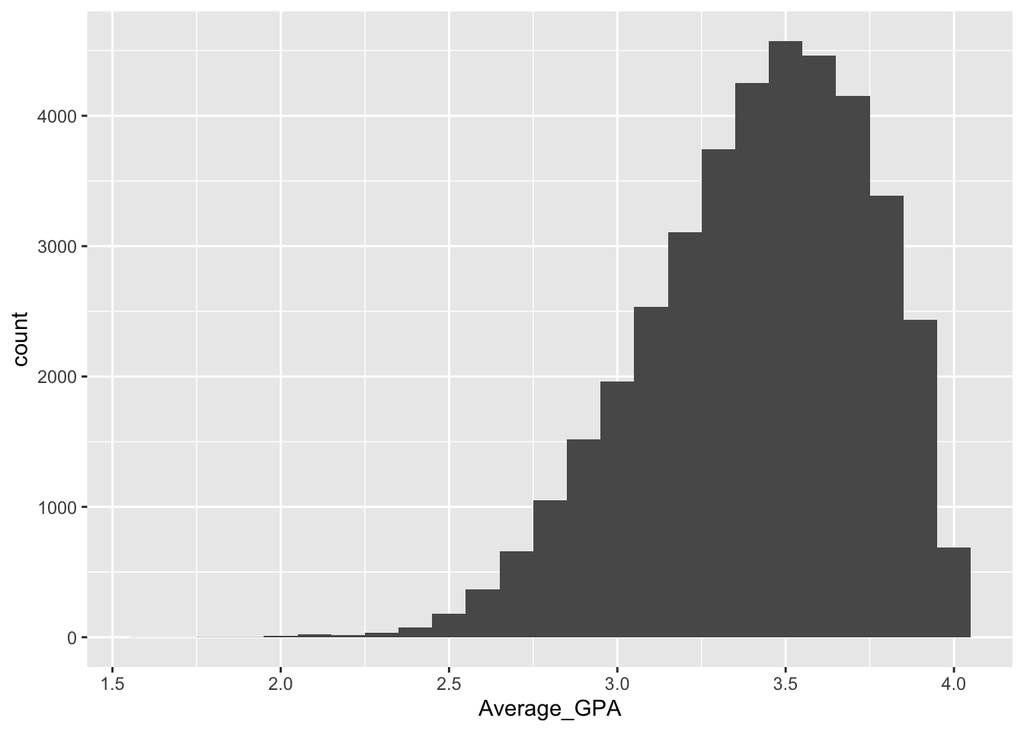

```r
ggplot(uw_grades_df, aes(x = Average_GPA)) +
  geom_histogram(binwidth = 0.1)
```

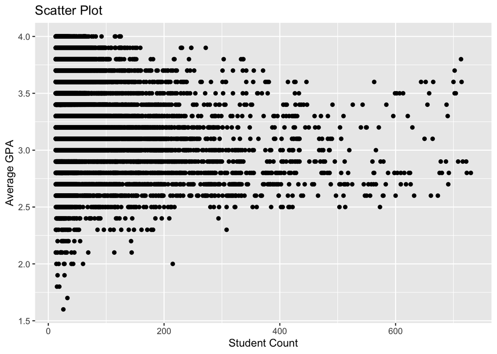

```r
ggplot(data = uw_grades_df) +
  geom_point(mapping = aes(x = Student_Count, y = Average_GPA))  +
  labs( title = "Scatter Plot", x = "Student Count", y = "Average GPA")
```

Out of the 39242 courses in the data set the Average gpa being a 3.41 is pretty good. While the average number of students in a class is 45 people, the class sizes are relatively small. The minimum number for a course is 100 which is the lowest to this day as well. With the highest being 750 I have yet to see a course with that high of a number.

```r
bio_df <- uw_grades_df |>
  filter(Program_Abv == "BIO")

econ_df <- uw_grades_df |>
  filter(Program_Abv == "ECON")
```

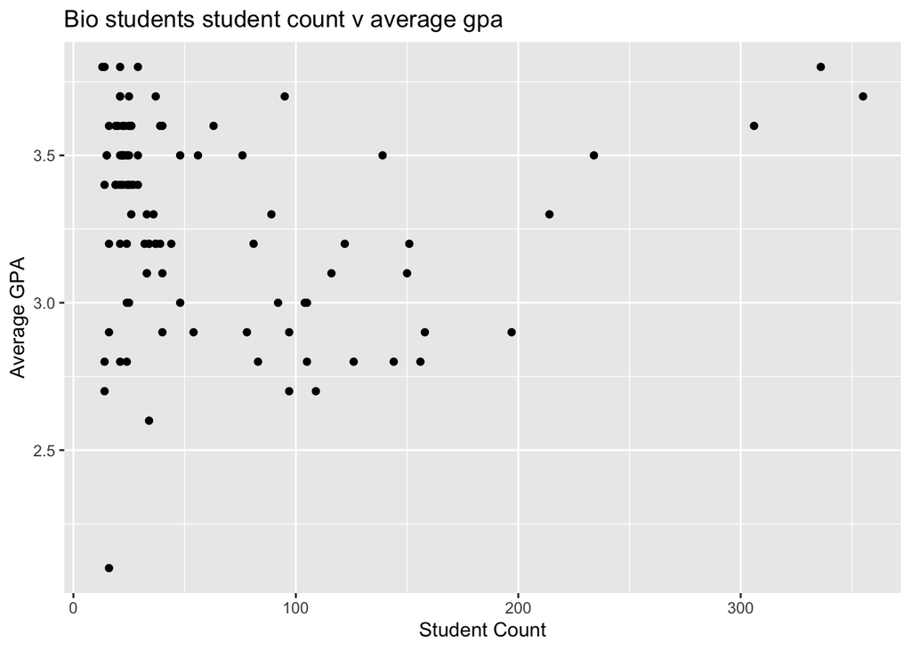

```r
ggplot(bio_df, aes(x = Student_Count, y = Average_GPA)) +
  geom_point(binwidth = 0.4) +
  labs(
    title = "Bio students student count v average gpa",
    x = "Student Count",
    y = "Average GPA"
  )
```

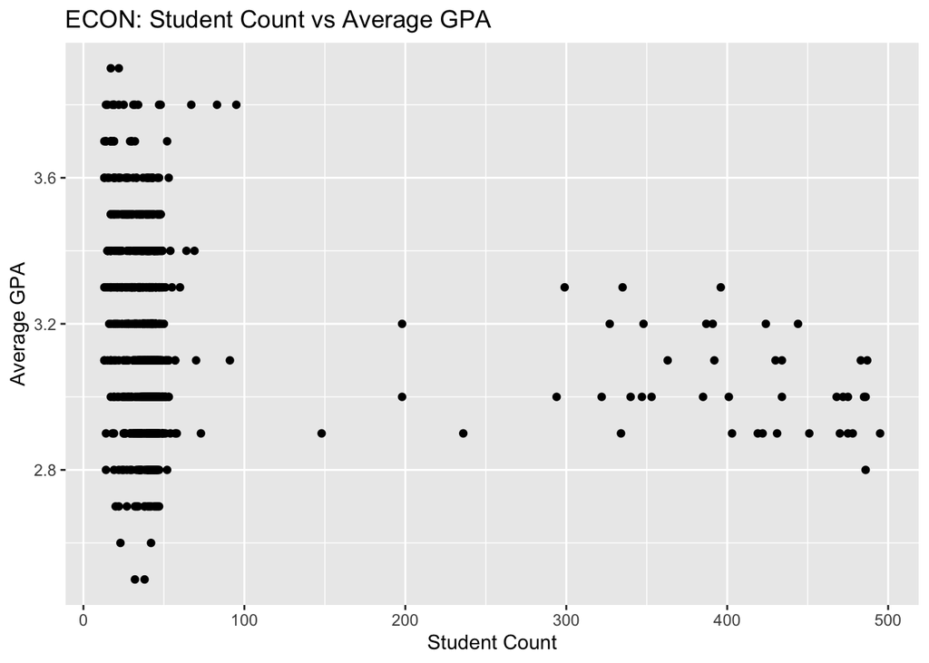

```r
ggplot(econ_df, aes(x = Student_Count, y = Average_GPA)) +
  geom_point(binwidth = 0.4) +
  labs(
    title = "ECON: Student Count vs Average GPA",
    x = "Student Count",
    y = "Average GPA"
  )
```

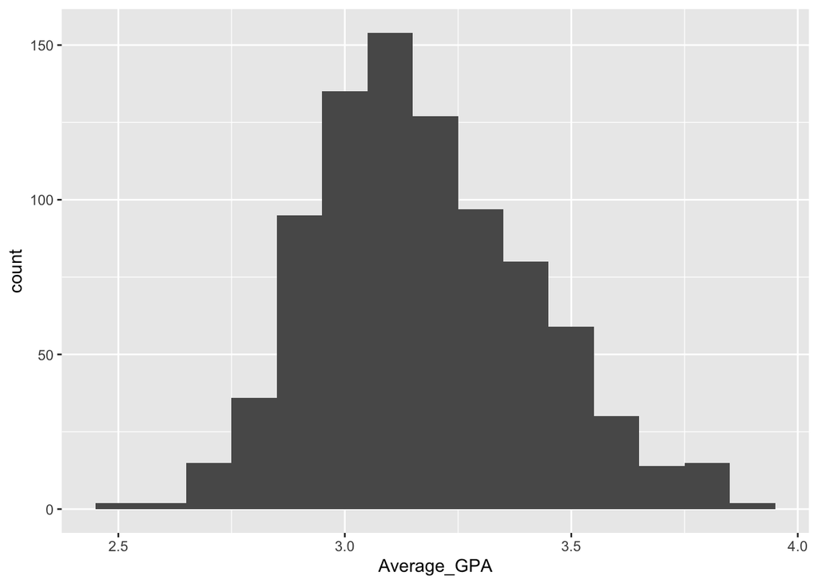

```r
ggplot(econ_df, aes(x = Average_GPA)) +
  geom_histogram(binwidth = 0.1)
```

```r
bio_summary <- bio_df |>
  summarise(
    num_courses = n(),
    avg_gpa = mean(Average_GPA, na.rm = TRUE),
    avg_students = mean(Student_Count, na.rm = TRUE),
    median_students = median(Student_Count, na.rm = TRUE)
  )

econ_summary <- econ_df |>
  summarise(
    num_courses = n(),
    avg_gpa = mean(Average_GPA, na.rm = TRUE),
    avg_students = mean(Student_Count, na.rm = TRUE),
    median_students = median(Student_Count, na.rm = TRUE)
  )

bio_summary
```

```
  num_courses avg_gpa avg_students median_students
1         100   3.284        60.81            30.5
```

```r
econ_summary
```

```
  num_courses  avg_gpa avg_students median_students
1         863 3.173812     54.87138              40
```

```r
Ais_df <- uw_grades_df |>
  filter(Program_Abv == "AIS")

ACCT_df <- uw_grades_df |>
  filter(Program_Abv == "ACCTG")
```

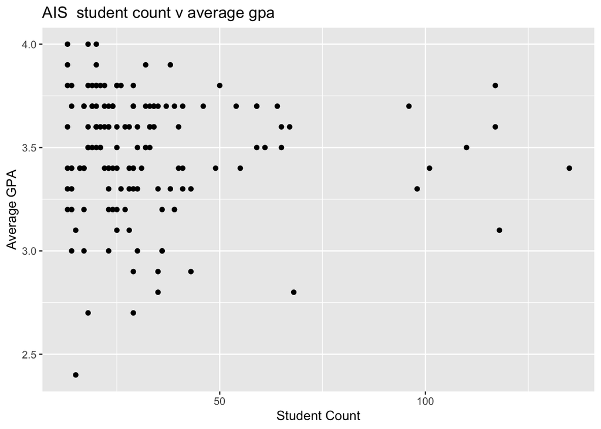

```r
ggplot(Ais_df, aes(x = Student_Count, y = Average_GPA)) +
  geom_point(binwidth = 0.4) +
  labs(
    title = "AIS  student count v average gpa",
    x = "Student Count",
    y = "Average GPA"
  )
```

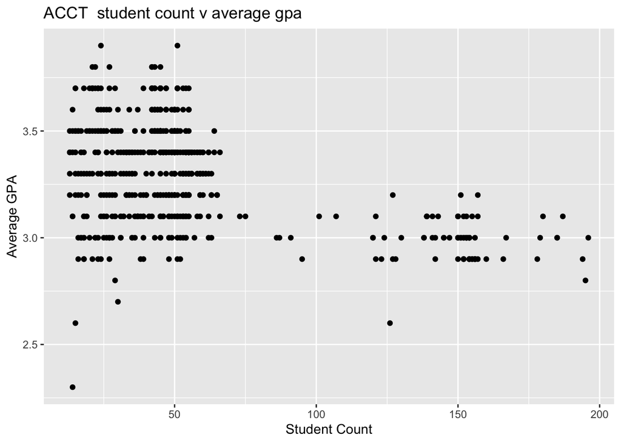

```r
ggplot(ACCT_df, aes(x = Student_Count, y = Average_GPA)) +
  geom_point(binwidth = 0.4) +
  labs(
    title = "ACCT  student count v average gpa",
    x = "Student Count",
    y = "Average GPA"
  )
```

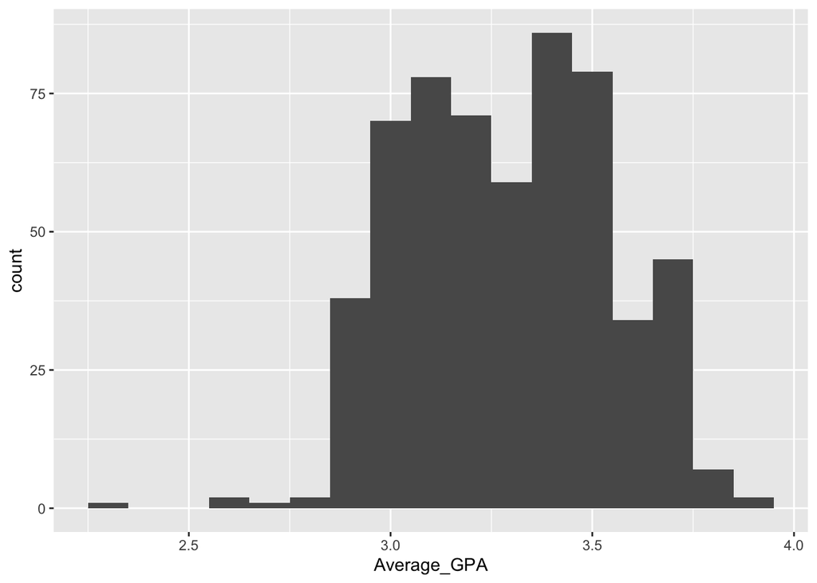

```r
ggplot(ACCT_df, aes(x = Average_GPA)) +
  geom_histogram(binwidth = 0.1)
```

```r
Ais_summary <- Ais_df |>
  summarise(
    num_courses = n(),
    avg_gpa = mean(Average_GPA, na.rm = TRUE),
    avg_students = mean(Student_Count, na.rm = TRUE),
    median_students = median(Student_Count, na.rm = TRUE)
  )

ACCT_summary <- ACCT_df |>
  summarise(
    num_courses = n(),
    avg_gpa = mean(Average_GPA, na.rm = TRUE),
    avg_students = mean(Student_Count, na.rm = TRUE),
    median_students = median(Student_Count, na.rm = TRUE)
  )

Ais_summary
```

```
  num_courses avg_gpa avg_students median_students
1         150   3.474         32.8            25.5
```

```r
ACCT_summary
```

```
  num_courses  avg_gpa avg_students median_students
1         575 3.290261     56.49217              47
```

I notice that there is a significant amount of difference between the number of courses for the two classes. There is way more accounting classes offered than AIS classes. The average gpa overall is higher in AIS classes than they are in accounting. While the average student count is higher in accounting than AIS we can assume more people are interested in taking those classes instead of AIS. Median of students in a class is higher in accounting than AIS.